# Part I - (Flights and performance)

## by (Andrea Headley)

## Investigation Overview

The overall goal of this explanatory report is to share some of the key insights gathered during the exploratory exercise done on the dataset that has data about flights performance across several cities in the US.

The key insights that will be presented are:

- the frequency of delays that carriers incurred and the variables that contributed to the delays
- the cities of origin with the most frequent flights
- airports with the best performance, in terms of early departures and delays
- the top ten busiest airports

## Dataset Overview

The data used for this project are segregated into two datasets - one with flight data for December 2019 and one with flight data for December 2020. The dataset from December 2019 has 625763 records and the dataset with flight data from 2020 December has 371357 records. The structure of both datasets is the same. Some of the key features of the datasets are:

- Departure Performance - Carrier departure times
- Departure and Arrival delays
- Carrier arrival times
- Cancellations and Diversions
- Causes of delays:
  - Carrier delays
  - Security delays
  - Weather delays
  - National Air Systems (NAS) delays
- Distribution of flights at origin and destination airports
- Airport performance

## Visualization 1

### Frequency of flights in December 2019

The following section investigates the frequency of flights covered by each carrier in December 2019 and in December 2020, separately. This involves taking a count of the occurrence of each carrier, then plotting a bar chart which shows the number of flights covered by each carrier.

### 1a. Frequency of flights in December 2019

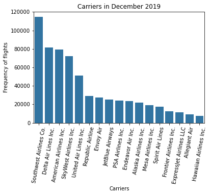

### 1b. Frequency of flights by new in December 2020

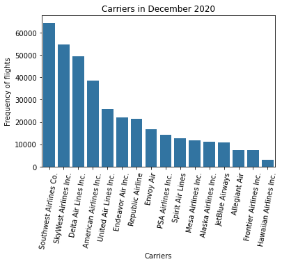

**Observation:** One key observation from the plots is the major reduction in flights in December 2020 in comparison to 2019, indicating there were less travelers, an obvious effect of the Covid-19 pandemic. Also, there was one less carrier in 2020, most probably impacted by the reduction in travelers due to the Covid pandemic. The carrier with the most flights in both years was SouthWest Airlines, but the number of flights in 2020 was approximately half the amount in 2019. In 2020, other carriers did not maintain the same place as in 2019. SkyWest Airlines had the next highest frequency of flights in 2020, replacing Delta Airlines and pushing American Airlines from 3rd in 2019 to 4th in 2020.

## Visualization 2

### 9. Reasons for flights cancellations

**Section 9 explores the different types of cancellations presented in the dataset, and plots them side by side to compare the frequency of occurrences in December 2019 and 2020.**

**Plots created sided by side using Seaborn**

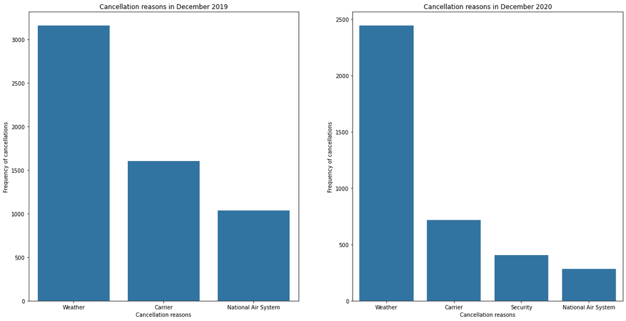

## Visualization 3

### 10. Frequency of flights from cities of origin

**Section 10 explores the different cities from which flights orginated in December 2019 and 2020, to see the frequency of flights, and plots them to visualize the frequency of occurrences.**

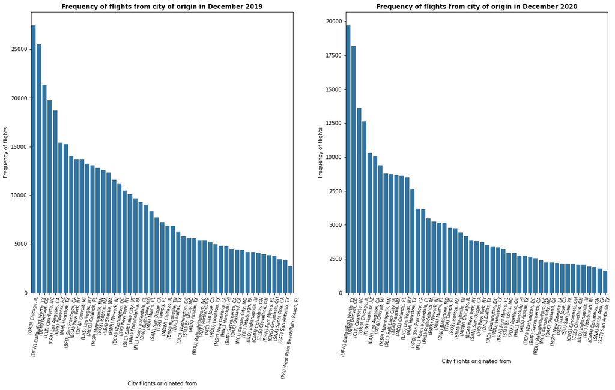

## Visualization 4

### 11. Frequency of flights at destination airports

**Section 11 explores the frequency of flights from destination airports in December 2019 and 2020, to see the frequency of flights, and provide plots that show the airports and frequency of flights.**

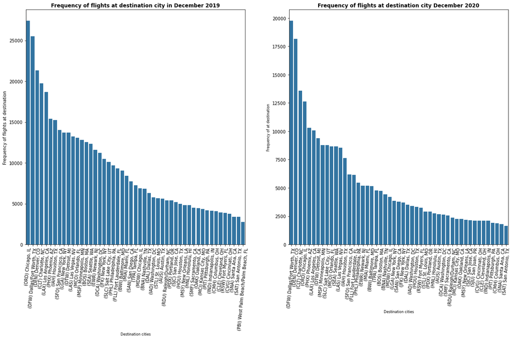

**Observation:** In 2019, Chicago (ORD) was the most travelled to destination airport, and the next 4 airports following were Dallas Forth Worth (DFW), Denver (DEN), Charlotte (CLT) and Los Angeles (LAX) - very similar to the findings from the analysis of the cities flights originated from. While four of the same airports remained within the top 5 in 2020, the order changed, with Chicago (ORD) falling to 4th place and Dallas Forth Worth (DFW) taking the top spot, followed by Denver (DEN) and Charlotte (CLT). Also in both charts, they have been significant differences in frequency of flights when comparing some airports listed adjacent in the plot. For example, in 2019, there is a big different in frequency of flights at Chicago (ORD) airport, with the number of flights exceeding 25,000 and the lowest under 5000 flights.

## Visualization 5

### 1. Range of departure delay each carrier endured

This explores the flight data to see the length of departure delays encountered by each carrier, during the months of December 2019 and December 2020. Visualizations are done using box plots.

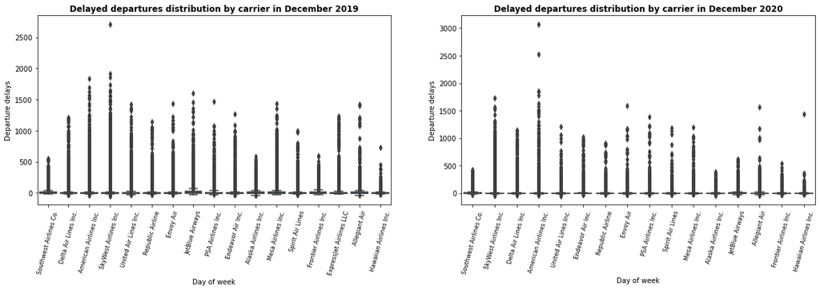

## Visualization 6

### 6. Top ten cities with early departures

This explores the top ten cities (by flight volume) with early flight departures

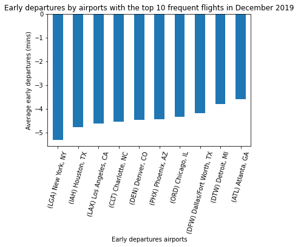

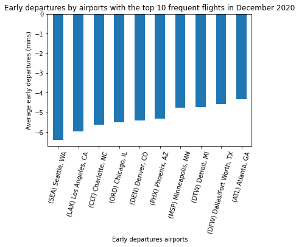

**Another view with box plots**

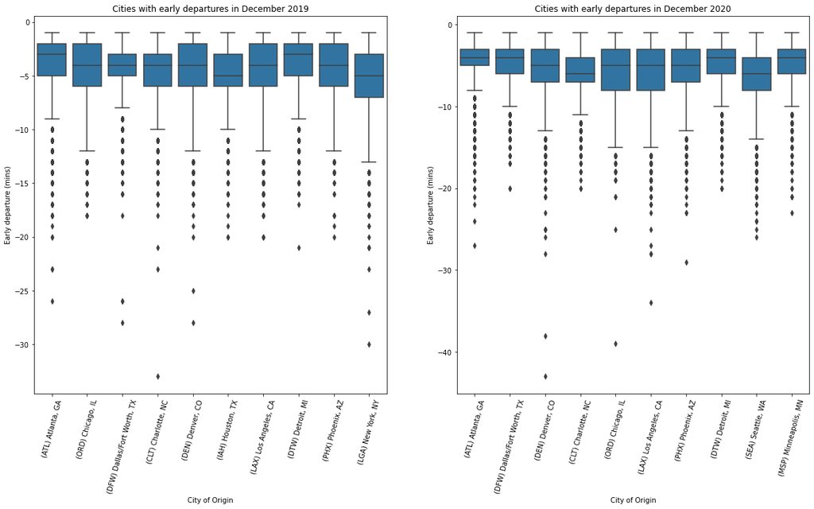

## Visualization 7

### 8. Cancellations vs delays (weather, security, NAS)

**This section explores the data to determine whether there is any correlation between cancellation and weather, security and NAS delays**

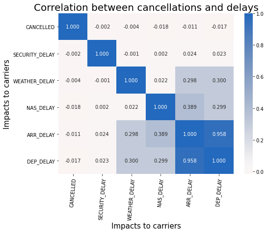

**The following is some additional plotting done to further explore the data to see if there are any correlations.**

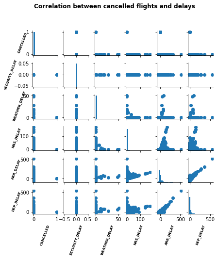

## Multivariate Exploration

## Visualization 8

### 1. Activities at top ten busiest airports

This section will explore the top 10 busiest airports (where flights originated) and produce a visual of the type of cancellations and volume of each cancellation type - 'Carrier', 'Weather', 'National Air System' and 'Security' impacting the airports.

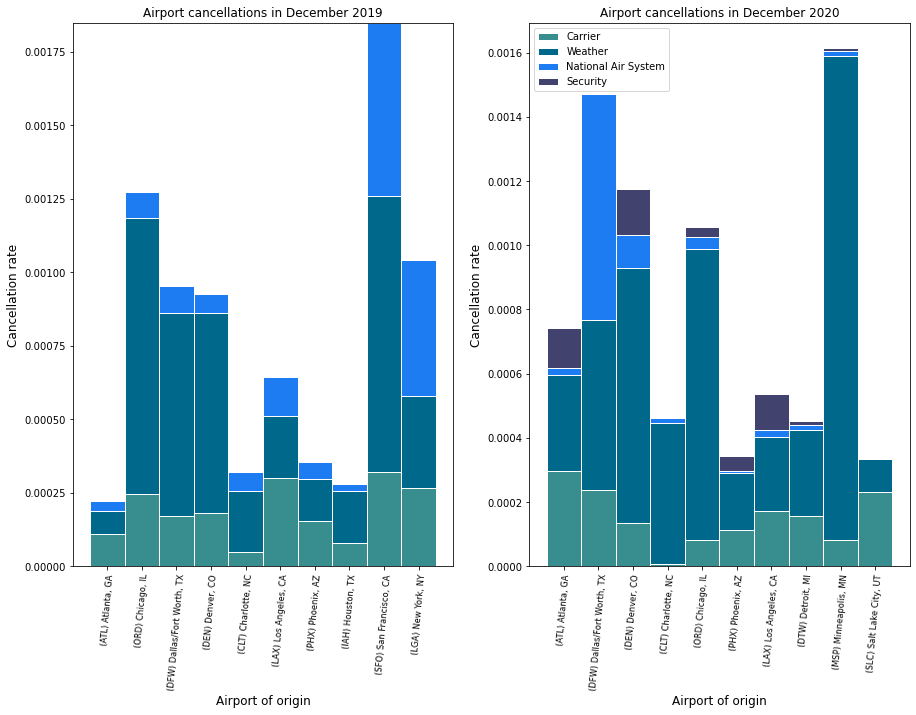

**Observation for December 2019:** Most of the cancellations were weather related, with Chicago and San Francisco having the highest rate. Whereas National Air System (NAS) cancellations were the least in most airports, except for San Francisco and New York La Guardia, which had significantly higher NAS delays. No security delays occured in the top ten airports where flights originated, and carrier related delays were the second lowest across. Overall, San Francisco airport had the largest combined cancellations, with Chicago following behind.

**Observation for December 2020:** Most of the cancellations were weather related, with Minneapolis (MSP) airport having the highest number of weather related delays, followed by Chicago (ORD) and Denver airports. Unlike in December 2019, there were some security related cancellations in 7 out of the 10 airports plotted, with Denver, Atlanta (ATL) and Los Angeles (LAX) amongst the highest. All of the airports experienced carrier related delays, with Charlotte (CLT) having the least impact. Of the four cancellation types, Dallas Forst Worth appears to have had a great share of the three of them, i.e. Carrier, Weather, and NAS.